# Analysing Twitter for Ubisoft

### Find the Expected Counts under each group and test for independence

The expected count of each cell, under the assumption that the two metrics are independent, will be the proportion users per bracket multiplied by the number of users in that status group. This implies that any cell will be:

- the product of the row sum, multiplied by the column sum divided by the number of counts.

This can be equivalently expressed as an outer product as shown in equation eqref:eq:1, in *R* this operation is denoted by the `%o%` operator, which is shorthand for the `outer()` function, this and other summary statistics may be evaluated as shown in listing *smst*.

The outer product is such that:

$$\mathbf{u} \otimes \mathbf {v} =\mathbf {u} \mathbf {v} ^{\textsf {T}}={\begin{bmatrix}u_{1}\\u_{2}\\u_{3}\\u_{4}\end{bmatrix}}{\begin{bmatrix}v_{1}&v_{2}&v_{3}\end{bmatrix}}={\begin{bmatrix}u_{1}v_{1}&u_{1}v_{2}&u_{1}v_{3}\\u_{2}v_{1}&u_{2}v_{2}&u_{2}v_{3}\\u_{3}v_{1}&u_{3}v_{2}&u_{3}v_{3}\\u_{4}v_{1}&u_{4}v_{2}&u_{4}v_{3}\end{bmatrix}}.$$

This means the matrix of expected frequencies can be expressed as an outer product thusly:

$$\begin{align}
\mathbf{\vec{e}}= \frac{1}{n} \times \begin{bmatrix} \sum^{n}_{j= 1} \left[ o_{1j} \right] \\ \sum^{n}_{j= 1}
\left[ o_{2j} \right] \\ \sum^{n}_{j= 1} \left[ o_{3j} \right] \\
\sum^{n}_{j= 1} \left[ o_{4j} \right] \\ \vdots \\
\sum^{n}_{j= 1} \left[ o_{nj} \right] \end{bmatrix}
\begin{bmatrix} \sum^{n}_{j= 1} \left[ o_{i1} \right] \\ \sum^{n}_{j= 1}
\left[ o_{i2} \right] \\ \sum^{n}_{j= 1} \left[ o_{i3} \right] \\ \cdots \\
\sum^{n}_{j= 1} \left[ o_{in} \right] \end{bmatrix} ^{\mathrm{T}} \label{eq:1}
\end{align}$$

Calculate Expected frequency of values under the assumption of independence.

```r
## ***** Calculate Summary Stats
n <- sum(vals)
bracket_prop <- colSums(vals) / n
metric_prop  <- rowSums(vals) / n
o <- vals
e <- rowSums(vals) %o% colSums(vals) / n
chi_obs <- sum((e-o)^2/e)
```

1. Testing Independence

   In order to test whether or not the distribution of users among brackets is independent of being a follower or friend a $\chi^{2}$ test may be used, this can be evaluated from a model or simulated, in *R*, the simulated test is shown in listing *chib*, this provides a $p$ -value < 0.0005, which means that the hypothesis of independence may be rejected with a high degree of certainty.

   Chi-Square testing for independence between friend and follower bin categories.

   ```r
   chisq.test(vals, simulate.p.value = TRUE)


   ##  Pearson's Chi-squared test with simulated p-value (based on 2000
   ##  replicates)
   ##
   ## data:  vals
   ## X-squared = 88.109, df = NA, p-value = 0.0004998
   ```

   1. From First Principles

      The $\chi^{2}$ statistic may be performed from first principles by randomly sampling the values at the rate at which they occured, tabulating those counts, measuring the $\chi^{2}$ -value and then repeating this many times.

      Because the samples are random they must be independent and average number of positives is hence an estimate for the *FPR*, which is in turn an estimate for the $p$ -value. This technique is demonstrated in listing *chif*, the p-value being returned as 0.0004, this value is consistent with the value produced by *R*'s built in `chisq.test` function and so is accepted.

      Performing a $\chi^{2}$ statistic from first principles

      ```r
      ## ***** Create Vectors of factor levels
      brackets <- unique(x_df$cat)
      metrics <- c("follower", "friend")

      ## ***** Simulate the data Assuming H_0
      ## I.e. assuming that the null hypothesis is true in that
      ## the brackets assigned to followers are independent of the friends
      ## (this is a symmetric relation)

      s <- replicate(10^4,{
        ## Sample the set of Metrics
        m <- sample(metrics, size = n, replace = TRUE, prob = metric_prop)

        ## Sample the set of Brackets (i.e. which performance bracket the user falls in)
        b <- sample(brackets, size = n, replace = TRUE, prob = bracket_prop)

        ## Make a table of results
        o <- table(m, b)
        o

        ## Find What the expected value would be
        e_sim <- t(colSums(e) %o% rowSums(e) / n)

        ## Calculate the Chi Stat
        chi_sim <- sum((e_sim-o)^2/e_sim)
        chi_sim

        ## Is this more extreme, i.e. would we reject null hypothesis?
        chi_sim > chi_obs

      })

      mean(s)

      ## [1] 4e-04
      ```

### FIXME Conclusion

The $p$ -value measures the probability of rejecting the null hypothesis when it is true, i.e. the probability of a detecting a *false positive*, a very small $p$ -value is hence good evidence that the null hypothesis should be rejected (because doing so would unlikely to be a mistake).

In saying that however the $p$ -value is distinct from the *power* statistic, which is a measure of //the probability of accepting the alternative hypothesis/ when it is true, a low $p$ -value is not a measurement of the probability of being correct.

Hence me way conclude, with a high degree of certainty, that the follower and friend counts are not independent of one another.

# 8.2 Finding Themes in tweets

## 8.2.8 Find Users with Above Average Friend Counts

Users with Above average Friend Counts can be identified by filtering the tweets data frame for two conditions:

1. non-duplicated `user-id`
2. `friend_count` greater than average

This can be acheived easily using the `dplyr` package as shown in *hfdp*, the top 20 of these users are shown in table *hfls* of the appendix

Use `dplyr` to Filter for Users with a high Friend Count

```r
select <- dplyr::select
filter <- dplyr::filter
interested_vars <- c("user_id", "friends_count")
(friend_counts <- tweets.company %>%
  select(interested_vars) %>%
  filter(!duplicated(user_id)))

(high_friends <- friend_counts %>%
  filter(friends_count > mean(friends_count, na.rm = TRUE)))

## Export Friends List
write.csv(high_friends[order(
  high_friends$friends_count,
  decreasing = TRUE),], file = "/tmp/highfriend.csv")
```

## 8.2.9 Find Users with Below Average Friend Counts

Users with high friends may be determined by a similar method (or by taking the complement of the high friends) as shown in listing *lfcd*, the lowest 20 of these users are shown in table *lftb* of the appendix.

Use `dplyr` to Filter for Users with a low Friend Count

```r
(low_friends <- friend_counts %>%
  filter(friends_count <= mean(friends_count, na.rm = TRUE)))

 low_friends <- low_friends[order(
   low_friends$friends_count,
   decreasing = TRUE),]

## Export Users
write.csv(low_friends[order(
  low_friends$friends_count,
  decreasing = FALSE),], file = "/tmp/lowfriend.csv")
```

## 8.2.10 Find the *Tweets* corresponding to users with high or low friend counts

The tweets corresponding to users with high and low friend counts can be identified by filtering the dataframe based on the friend count and using that to the index the tweets from the data frame [^1], alternatively it is possible to test whether or not the ID of a user appears in the high or low vector set using the `%in%` operator as shown in listing *8210*.

Identify tweets corresponding to users with high and low friend counts

```r
## Method 1
friend_test <- tweets.company$friends_count > mean(tweets.company$friends_count)
tweets_high <- tweets.company$text[friend_test]
tweets_low <- tweets.company$text[!friend_test]

## Method 2                                                                 :15b5a74:
tweets_high <- tweets.company$text[tweets.company$user_id %in%  high_friends$user_id]
tweets_low  <- tweets.company$text[tweets.company$user_id %in%  low_friends$user_id]
tweets <- c(tweets_high, tweets_low)

## Mark as High or Low
tweets_low <- cbind(tweets_low, rep("Low_Friend", length(tweets_low)))
tweets_high <- cbind(tweets_high, rep("High_Friend", length(tweets_high)))
tweets <- as.data.frame(rbind(tweets_high, tweets_low))
tweets$Friend_Status  <- factor(tweets$Friend_Status)
```

## 8.2.11 Clean the tweets

### Create a Corpus Object

In order to clean the tweets it is necessary to create a corpus object as shown in listing *cpmk*, it is possible to pass a dataframe source in order to include the user ID, this isn't strictly necessary however because the `tm` package preserves order when performing transformations.

Create a Corpus from the tweets

```r
tweet_source <- tm::VectorSource(tweets$text)
tweet_corpus <- tm::Corpus(x = tweet_source)
```

Next it is necessary to choose an enoding, a primary consideration of this is whether or not the use of *emoji* characters will influence the model performance. There is research to suggest that Emoji's can be used as predictive features cite:lecompte2017 and that they can improve *sentiment analysis* models cite:shiha2017 that implement a *bag of words* approach. For these reasons *emoji* characters will be preserved and [UTF-8](http://www.utf-8.com/) implemented.

In order to encode the data as *UTF-8*, the `iconv` function can be used as shown in listing *icv*.

Encode the Data as UTF-8

```r
encode <- function(x) {
    iconv(x, to = "UTF-8")
#    iconv(x, to = "latin1")
  #  iconv(x, to = "ASCII")
}

tweet_corpus <- tm_map(x = tweet_corpus, FUN = encode)
tweet_corpus_raw <- tweet_corpus
```

### Process the tweets

Before analysis the tweets should be modified to remove characters that may interfere with categorising words, this is referred to as cleaning, in particular the following should be implemented:

1. Remove URL's
2. Remove Usernames
3. remove numbers
4. remove punctuation
5. remove whitespace
6. case fold all characters to lower case
7. remove a set of stop words
8. reduce each word to its stem

In particular it is important to reduce words to lower case before removing stop words otherwise an unorthodox use of capitalisation may prevent the word from being removed throughout.

The stop word `ubisoft` will also be used, this was the query term so it's expected to turn up at a very high frequency, the words `can` and `'s` also occured quite frequently and so were removed.

The cleaning can be implemented by mapping functions over the corpus, which is fundamentally a list, this can be performed via the `tm_map` function as shown in listing *cltw*.

Use the `tm_map` function to clean the tweets

```r
mystop <- c(stopwords(), "’s", "can", "ubisoft", "@ubisoft", "#ubisoft")# <<stphere>>

clean_corp <- function(corpus) {
  ## Remove URL's
  corpus <- tm_map(corpus,content_transformer(function(x) gsub("(f|ht)tp(s?)://\\S+","",x)))
  ## Remove Usernames
  corpus <- tm_map(corpus,content_transformer(function(x) gsub("@\\w+","",x)))
  ## Misc
  corpus <- tm_map(corpus, FUN = removeNumbers)
  corpus <- tm_map(corpus, FUN = removePunctuation)
  corpus <- tm_map(corpus, FUN = stripWhitespace)
  corpus <- tm_map(corpus, FUN = tolower)
  corpus <- tm_map(corpus, FUN = removeWords, mystop)
  ## stopwords() returns characters and is fead as second argument
  corpus <- tm_map(corpus, FUN = stemDocument)
  return(corpus)
}

tweet_corpus_clean <- clean_corp(tweet_corpus)
```

## 8.2.12 Display the first two tweets before/after processing

The tweets can be viewed from inside the corpus by selecting with the `[` function [^2] as demonstrated in listing *ispt*, the first *tweet* was rendered empty by the processing and the following two tweets were:

- *Pre-Processing*
  > - "Today was the first time in over a month that I have gone 24 hours without checking the coronavirus death toll. Thanks `@Ubisoft`."
  > - "@btwimskrank `@TheDivisionGame` `@UbiMassive` `@Ubisoft` `@jgerighty` `@hamishbode` `@Tideman92` `@janeyo_jane` `@slimjd` Very odd… I'll even post a video about it."
- *Post-Processing*
  > - "today first time month gone hour without check coronavirus death toll thank"
  > - "odd ill even post video"

Load the Packages for *R*

```r
tweet_corpus_raw[[1]]$content
tweet_corpus_clean[[1]]$content
tweet_corpus_raw[[2]]$content
tweet_corpus_clean[[2]]$content
tweet_corpus_raw[[3]]$content
tweet_corpus_clean[[3]]$content
```

## 8.2.13 Create a Term Document Matrix

### Apply Weighting Manually

1. Create Term Documen Matrix

   A term Document matrix (and it's transpose) can be constructed from a `corpus` using the `tm:TermDocumentMatrix` function as shown in listing *tdm*.

   Load the Packages for *R*

   ```r
   tweet_matrix_tdm <- TermDocumentMatrix(tweet_corpus_clean)
   tweet_matrix_dtm <- DocumentTermMatrix(tweet_corpus_clean)
   ```

2. Apply TF-IDF Weighting

   Weighted term frequency is defined as shown in equation eqref:tfidf, where:
   - $f_{d,t}$ is the frequency of a given term $t$ in the a document $d$
   - $w_{d,t}$ is the weight of a given term $t$ in the a document $d$
   - $N$ is the number of documents
   - $f_{t}$ is the number of documents containing $t$

   $$\begin{aligned}
   w_{d, t} &=\mathrm{TF}_{t} \times \mathrm{IDF}_{d, t} \\
   &=\log _{e}\left(f_{d, t}+1\right) \log _{e}\left(\frac{N}{f_{t}}\right) \label{tfidf}
   \end{aligned}$$

   This would requre multiplying each term of each row of the $\mathrm{TF}_{t}$ matrix by the corresponding vector element of $\mathrm{IDF}_{d,t}$, this can be implemented by taking the matrix product of a diagonalised matrix, this is shown in listing *mytfidf*.

   Apply TF-IDF Weigting

   ```r
   N <- nrow(as.matrix(tweet_matrix_dtm))   # Number of Documents
   ft=colSums(as.matrix(tweet_matrix_dtm) > 0) #in how many documents term t appeared in,

   TF <- log(as.matrix(tweet_matrix_dtm) + 1)  # built in uses log2()
   IDF <- log(N/ft)

   tweet_weighted           <- TF %*% diag(IDF)
   colnames(tweet_weighted) <- colnames(tweet_matrix_dtm)
   ```

   There is however a function built in to the `tm` package that will weight term document matrices and this will instead be implented to analyse the data because it will produce more maintainable code.

### Apply Weighting with Built in Function

In order to create a term document matrix (and its transpose) with TF-IDF weighted values, the `weighting` argument may be specified as `weightTfIdf` by passing an appropriate list to the `control` argument of the `TermDocumentMatrix`, as shown in listing *btdm*

Create a Document Term Matrix by transforming a Term Document Matrix

```r
tweet_weighted_tdm <- tm::TermDocumentMatrix(x = tweet_corpus_clean, control = list(weighting = weightTfIdf))
tweet_weighted_dtm <- as.DocumentTermMatrix()  %>%
                        as.matrix()
```

### Remove Empty Documents

Empty Documents may be removed from the matrix by a logical test as shown in listing *emp* [^3] this provides that 328 documents were empty following the processing. A summary of the first rows and columns of this matrix, following the removal of empty documents, is provided in table *tfidf* of the appendix.

Load the Packages for *R*

```r
null = which(rowSums(as.matrix(tweet_weighted_dtm)) == 0)
rowSums(as.matrix(tweet_weighted_dtm)==0)

if(length(null)!=0){
  tweet_weighted_dtm = tweet_weighted_dtm[-null,]
}

length(null)

## [1] 328
```

## 8.2.14 How many Clusters are there

### Use Cosine Distance

In order to consider clustering, it can be more effective to consider the distance between the weigted documents in terms of cosine distance, the cosine distance can be calculated from the euclidean distance using the identity shown in eqref:cos, and this can be performed in *R* by taking the matrix product of a diagonalised matrix as shown in listing *dist*.

$$\begin{align}
\mathrm{dist}\left( \mathbf{X}, \mathbf{Y} \right)= \left| \left| \mathbf{X}-\mathbf{Y} \right| \right| \\
&= \sqrt{\sum^{n}_{i= 1} \left[ \left( x_i-y_i \right)^2 \right] } \\
\mathrm{dist}\left( \mathbf{X}, \mathbf{Y} \right)^2&= \sum^{n}_{i= 1} \left[ \left( x_i-y_i \right)^2 \right] \\
&= \sum^{n}_{i= 1} \left( x^2 \right)+ \sum^{n}_{i= 1} \left( y_i^2 \right)+ 2 \sum^{n}_{i= 1} \left( x_iy_i \right) \\
&= 1+ 1 + 2 \times \frac{\sum^{n}_{i= 1} \left( x_iy_i \right)}{\left( 1 \right) }\\
&= 2+ 2\times \frac{\sum^{n}_{i= 1} \left( x_iy_i \right)}{\left| \left| \mathbf{X} \right| \right|\times \left| \left| \mathbf{Y} \right| \right|}\\
&= 2+ 2 \cos\left( \mathbf{X}, \mathbf{Y} \right)\\
\ \\
& \implies \left( 1- \cos\left( \mathbf{X}, \mathbf{Y} \right) \right) = \frac{\mathrm{dist}\left( \mathbf{X}, \mathbf{Y} \right)}{2} \label{cos}
\end{align}$$

Load the Packages for *R*

```r
norm.tweet_weighted_dtm = diag(
                    1/sqrt(rowSums(tweet_weighted_dtm^2))
                    ) %*% tweet_weighted_dtm
D =dist(norm.tweet_weighted_dtm, method = "euclidean")^2/2
```

### Project into Euclidean Space

The cosine distance however is not appropriate to perform clustering on and so instead should be projected back into euclidean space, this can be acheived using *Multi-Dimensional Scaling* via the `cmdscale` functionas shown in listing *mds*. The distance is a measure of between document distance so the number of dimensions should correspond to the number of documents, however, if there are zero-value eigenvalues, these dimensions won't help explain the data in the projection, hence the number of eigenvalues has been used as the dimension of projection in this case.

Load the Packages for *R*

```r
l <- min(nrow(tweet_weighted_dtm),
         ncol(tweet_weighted_dtm))
ev <- eigen(tweet_weighted_dtm[1:l, 1:l])
k <- (ev$values != 0) %>% sum()

mds.tweet_weighted_dtm <- cmdscale(D, k=k) #TODO What should K be? see issue #10
```

### Measure Within Cluster Variance

In order to determine the appropriate number of clusters, the within cluster variance can be measurd, the number of clusters at which this value ceases to decrease is indicative of a potentially appropriate number of clusters. This is implemented in listing *ssw* and shown in figure *sswp*.

Use a loop to evaluate the performace of various cluster models, plot this with *ggplot2*

```r
set.seed(271)
n = 15 # Assume it bends at 7 clusters
SSW = rep(0, n)
for (a in 1:n) {
  K = kmeans(mds.tweet_weighted_dtm, a, nstart = 20)
  SSW[a] = K$tot.withinss
  paste(a*100/n, "%") %>% print()
}
SSW


SSW_tb <- tibble::enframe(SSW)
ggplot(SSW_tb, aes(x = name, y = value)) +
  geom_point(col = "#Cd5b45", size = 5) +
  geom_line(col = "#Da70d6") +
  geom_vline(xintercept = 7, lty  = 3, col = "blue") +
  theme_bw() +
  labs(x = "Number of Clusters",
       y = "Within Cluster Sum of Square Distance",
       title = "Within Cluster Variance across Clusters")
```

Figure *sswp* Indicates a sudden stop of decrease in variance at 7 clusters and following that the within cluster variance begins to decrease at a slightly slower rate. For this reason 7 could be an appropriate candidate for the number of clusters, however the minimal amount of change in the within-cluster variance indicates that the data is most likely not clustered at all.

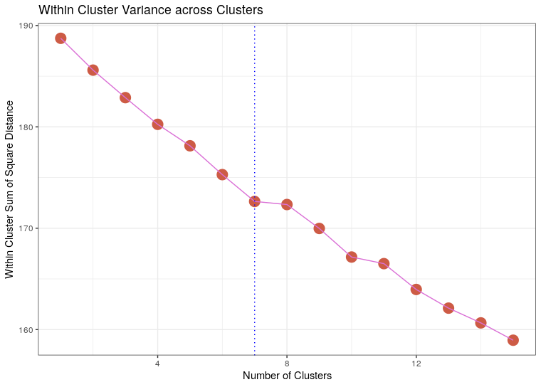

## 8.2.15 Find the Number of tweets in each cluster

Moving forward we'll use 3 clusters, 7 is too large and a smaller number will likely be more effective at categorising the data (particularly given that the stratification of the data appears to be quite limited from figure *sswp*). The number of tweets in a cluster may be measured by using the `table` function as shown in listing *tab* and table *tabo*.

The `table` function can count the number of tweets per cluster.

```r
K = kmeans(mds.tweet_weighted_dtm, 3, nstart = 20)
table(K$cluster)
```

Number of tweets in each cluster identified by $k$ means clustering

[output not shown]

## 8.2.16 Visualise the Clusters

The clusters can be projected into 2D *Euclidean*-Space using *Multi-Dimensional Scaling*, these dimensions would represent the first two principle components of the cosine distance of the weigted tweets. This is demonstrated in listings *cmds*. A plot of the friend countstaus mapped to shape and clusters mapped to colour is demonstrated in listing *pt1c* shown in *pt2*, In order to get a better understanding of the distribution of friend counts a plot of the friend count status mapped to colour is demonstrated in listing *pt2c* and shown in figure *pt2*.

Use *Multi-Dimensional* scaling to project the data into 2 dimensions

```r
MDS_Euclid_2D <- cmdscale(D, k=2) #TODO What should K be? see issue #10
mds_data$Cluster       <- factor(mds_data$Cluster)

if (nrow(MDS_Euclid_2D[,1:2]) == length(K$cluster)
   && length(K$cluster) == nrow(tweets[-null,])) {
mds_data <- cbind(MDS_Euclid_2D[,1:2], "Cluster" = K$cluster, tweets[-null,])
}

mds_data$Cluster       <- factor(mds_data$Cluster)
names(mds_data)[1:2] <- c("MDS1", "MDS2")
```

Create a plot of the distribution of Friends among Clusters as shown in figure *pt1*

```r
ggplot(pca_data, aes(x = MDS1, y = MDS2, col = Friend_Status)) +
  geom_point(aes(shape = Cluster), size = 2) +
  stat_ellipse(level = 0.95) +
  theme_classic() +
  labs(main = "Principal Components of Twitter Data",
       x = TeX("MDS_1"), y = TeX("MDS_2")) +
  scale_color_discrete(label = c("High Friends", "Low Friends")) +
  guides(col = guide_legend("Friend Count \n Status"))
```

Create a plot of the distribution of Friends Count Status as shown in figure *pt2*

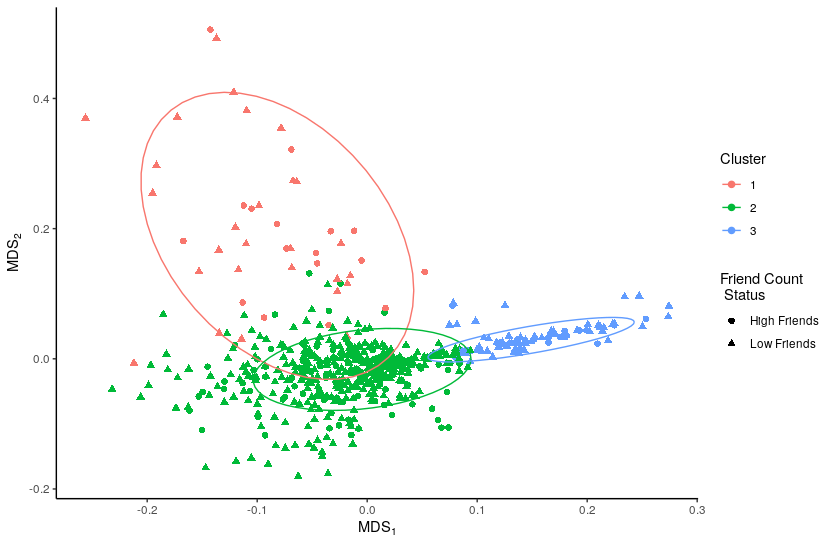

[figure not shown]

```r
ggplot(pca_data, aes(x = MDS1, y = MDS2, col = Cluster)) +
  geom_point(aes(shape = Friend_Status), size = 2) +
  stat_ellipse(level = 0.9) +
  theme_classic() +
  labs(main = "Principal Components of Twitter Data",
       x = TeX("MDS_1"), y = TeX("MDS_2")) +
  scale_shape_discrete(label = c("High Friends", "Low Friends")) +
  guides(shape = guide_legend("Friend Count \n Status"))
```

## 8.2.17 Comment on the Visualisation

Figure *pt1* indicates that altough there isn't a clear distinction between clusters there is seperation of the tweets in such a way that does allow some degree of classification to occur. Figure *pt1* and *pt2* both indicate that having many or few friends is reasonably independent of the cluster that the tweet belongs to.

## 8.2.18 Cluster with Highest Number Friends

The Number of above or below friends corresponsing to a given cluster can be tabulated by using the `table` function as shown in listing *tfc* and table *tfct*, this indicates that there is a difference in the proportion of users with above average friend counts between clusters with cluster `#1` having the highest proportion of users with above average friend counts.

Tabulate the distribution of friends in

```r
(clust_friend <- table(
  pca_data[,names(pca_data) %in% c("Cluster", "Friend_Status")])
)

cbind(clust_friend,
        "Proportion" = signif(
            (clust_friend[,1] / rowSums(clust_friend)),
            2)
      )
```

Above Average Friend Counts Across Clusters

| *Cluster* | *Above Average* | *Below Average* | *Proportion* |
| --- | --- | --- | --- |
| `1` | 17 | 27 | 0.39 |
| `2` | 141 | 407 | 0.26 |
| `3` | 16 | 64 | 0.20 |

## 8.2.18 Sample Tweets from cluster

Tweets can be sampled from the clusters by using the `sample` function with a logical test, this can be combined with a `for` loop as shown in listing *8218*, this provides the following output.

> - **Cluster 1**
>   - [@BelovedOfBayek](https://twitter.com/search?q=%40BelovedOfBayek&src=typed_query) [@BayekOfSiwa](https://twitter.com/search?q=%40BayekOfSiwa&src=typed_query) [@assassinscreed](https://twitter.com/search?q=%40assassinscreed&src=typed_query) [@Ubisoft](https://twitter.com/search?q=%40Ubisoft&src=typed_query) [@UbisoftMTL](https://twitter.com/search?q=%40UbisoftMTL&src=typed_query) [@Captured_Collec](https://twitter.com/search?q=%40Captured_Collec&src=typed_query) [@GamerGram_GG](https://twitter.com/search?q=%40GamerGram_GG&src=typed_query) [@_GameScreenshot](https://twitter.com/search?q=%40_GameScreenshot&src=typed_query) And those smiles - and love - are contagious. Believe me, it makes me very happy! What you have is special! 💗 ~ Steffi
>   - [@Ubisoft](https://twitter.com/search?q=%40Ubisoft) why is it wen I headshot sumone why don’t it register a headshot is a 1 shot kill fix your game sir
>   - [@BikiniBodhi](https://twitter.com/search?q=%40BikiniBodhi) I think we need another movement going. Obviously Ubisoft already has plans for the next few releases of ops but we really need an Op whose ability is to reinforce more walls than others. Especially another castle on the team but for walls. Like 4 walls instead of 2.
>   - The United Arab Emirates logged into my Ubisoft account. For why?
>   - [@Atalagummy](https://twitter.com/search?q=%40Atalagummy) Está gratis este finde en lo de ubisoft creo
> - **Cluster 2**
>   - Here's everything you need to know about Ubisoft's Watch Dogs Legion in Hindi - Release date, Story - Everything we know about it till now. https://t.co/B4lMshJdqw via [@YouTube](https://twitter.com/search?q=%40YouTube)
>   - [@Rainbow6Game](https://twitter.com/search?q=%40Rainbow6Game) [@TheGodlyNoob](https://twitter.com/search?q=%40TheGodlyNoob) I have never seen a game company ruin their reputation so fast and so careless as Ubisoft
>   - tiltei com a ubisoft, dei block na minha conta sem querer, to mt puto, real
>   - My first game that really hyped me was a game called rolling thunder back in the 80’s https://t.co/mPWim2hwVY
>   - [@videogamemorals](https://twitter.com/search?q=%40videogamemorals) [@PartisanClown](https://twitter.com/search?q=%40PartisanClown) Two more remakes of Lunar: The Silver Star, Lunar Legend and Lunar: Silver Star Harmony, were released in 2002 by Media Rings and Ubisoft and in 2009 by GungHo Online Entertainment and Xseed Games, respectively.\
> - **Cluster 3**
>   - [@Ubisoft](https://twitter.com/search?q=%40Ubisoft) [@UbisoftSupport](https://twitter.com/search?q=%40UbisoftSupport) crossplay between xbox and pc for Division 2 please?
>   - [@tornado_raphi](https://twitter.com/search?q=%40tornado_raphi) [@Ubisoft](https://twitter.com/search?q=%40Ubisoft) [@UbisoftDE](https://twitter.com/search?q=%40UbisoftDE) Haha wollte auch einmal schlau sein :(
>   - `@Ubisoft` I was in the middle in a game waiting for us to spawn in and it took forever and it somehow kicked me from the game for inactivity. Anyway to fix this https://t.co/Uz1yZ73R4M
>   - [@Operatedleech87](https://twitter.com/search?q=%40Operatedleech87) Yo lo veia al revez algo de Ubisoft en Girls Frontline, pero igual un juego en consola jalaria.
>   - [@VGPNetwork](https://twitter.com/search?q=%40VGPNetwork) [@GamerGram_GG](https://twitter.com/search?q=%40GamerGram_GG) [@Ubisoft](https://twitter.com/search?q=%40Ubisoft) Haha.. I love that film!

Sample Tweets from the Individual Clusters

```r
set.seed(8923)
  for(i in 1:3) {
    n <- sample(which(pca_data$Cluster == i), size = 5)
    print(tweets$text[n])
    print("===========================")
    print("===========================")
  }
```

## 8.2.19 Identify themes in the Tweets

### Highest Friends Count

The themes in the cluster with the highest friend count are:

- Discussion about upcoming titles
  - For example the *Sunborn-Ubisoft* collaboration
    - This is where the use of `collab` comes from in figure *wc1*
  - The upcoming *Division 2* release
- Multiplayer games.

### Lowest Friends Count

The themes in the cluster with the lowest friends count are:

- Discussion about older titles
  - e.g. `mincemeat` refers to *Farcry*, mozzi is a *Rainbow 6* character
  - the recurring use of `remember` and `earliest`
- Console games and crossplay between them
- Feature Requests

## 8.2.20 Create WordClouds

Creating a wordcloud from the stemmed words will make for a poor visualisation while creating a wordcloud based merely on the frequency of words will poorly identify words central to the theme of the cluster.

In light of this, the most appropriate method to generate wordclouds for the purpose visualisising the themes of the clusters is to create a document term matrix based on a corpus cleaned without word stemming as shown in listing *wcm0*. Following that wordclouds can then be generated by indexing for the cluster, this is demonstrated in listing *wcm* and shown in figures *wc1* and *wc3*.

Apply *TF-IDF* weighting to an unstemmed corpus and then use a `for` loop to create wordclouds corresponding to each cluster.

```r
clean_corp_ns <- function(corpus) {
  ## Remove URL's
  corpus <- tm_map(corpus,content_transformer(
    function(x) gsub("(f|ht)tp(s?)://\\S+","",x)))
  ## Remove Usernames
  corpus <- tm_map(corpus,content_transformer(function(x) gsub("@\\w+","",x)))
  ## Misc
  corpus <- tm_map(corpus, FUN = removeNumbers)
  corpus <- tm_map(corpus, FUN = removePunctuation)
  corpus <- tm_map(corpus, FUN = stripWhitespace)
  corpus <- tm_map(corpus, FUN = tolower)
  corpus <- tm_map(corpus, FUN = removeWords, mystop)
  ## stopwords() returns characters and is fead as second argument
  return(corpus)
}

tweet_corpus_clean_ns <- clean_corp(tweet_corpus)

tweet_raw_dtm <- tm::TermDocumentMatrix(x = tweet_corpus_ns,
   control = list(weighting = weightTfIdf)) %>%
  as.DocumentTermMatrix()  %>%
  as.matrix()

null = which(rowSums(as.matrix(tweet_matrix_dtm)) == 0)
length(null)

(rowSums(as.matrix(tweet_matrix_dtm))) %>% table()
if(length(null)!=0){
  tweet_matrix_dtm = tweet_matrix_dtm[-null,]
}
```

Apply *TF-IDF* weighting to an unstemmed corpus and then use a `for` loop to create wordclouds corresponding to each cluster.

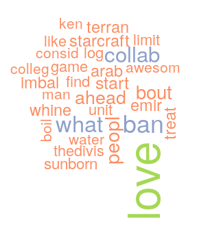

[figure not shown]

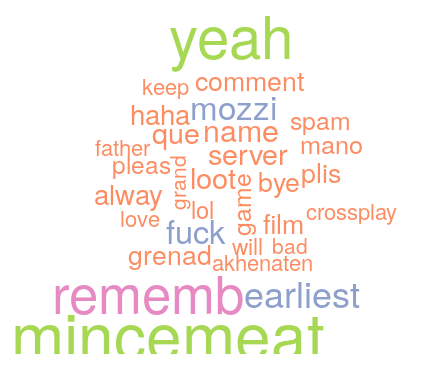

```r
i <- 1

for (i in c(1,3)) {
  n <- which(pca_data$Cluster == i)

  (relevant <- sort(apply(tweet_raw_dtm[n,], 2, mean),
    decreasing = TRUE)[1:30]) %>% head()

  p <- brewer.pal(n = 5, name = "Set2")
    wordcloud(
    words = names(relevant),
    freq = relevant,
    colors = p,
    random.color = FALSE
  )

}
```

## 8.2.21 Use a Dendrogram to Display the Themes

A Dendrogram can be used to display the themes of the higest and lowest clusters. In order to do this the most frequent words of a cluster need to be filtered out in order to reduce the dimensions of the dendrogram, following that a dendrogram may be made to model the cosine distance between the terms. To acheive this in **R** the identity from equation eqref:cos can be used and then a dendrogram modelled over the term document matrix.

### Highest Friend Count

Any word that occurs more than once was a candidate for the dendrogram visualising the themes of the cluster with the highest number of friends. This dendrogram is shown in figure *dn1* and the corresponding code to produce it is provided in listing *dn1c*.

### Lowest Friend Count

Create a dendrogram of the terms in the cluster with the higest friends count, average linkage was used.

```r
## Filter the Data To match the Cluster
tweet_weighted_dtm_c1 <- tweet_weighted_dtm[pca_data$Cluster==1, ]

## Choose terms of a given frequency to reduce the dimensions
frequent.words = which(colSums(tweet_weighted_dtm_c1 > 0) > 1)
term.matrix = tweet_weighted_dtm_c1[,frequent.words]

## In order to use the Cosine Distance Make each vector have a
## magnitude of 1
unit_term.matrix = term.matrix %*% diag(1/sqrt(colSums(term.matrix^2)))

## Preserve the column Names
colnames(unit_term.matrix) = colnames(term.matrix)
colnames(unit_term.matrix)

## Find the Cosine Distance between the Terms
## (Distance between terms so transpose)
t(unit_term.matrix)
D = dist(t(unit_term.matrix), method = "euclidean")^2/2

## Perform Heirarchical Clustering
h = hclust(D, method="average")
plot(h, main = "Themes of Cluster with Highest Friend Count")
```

[figure not shown]

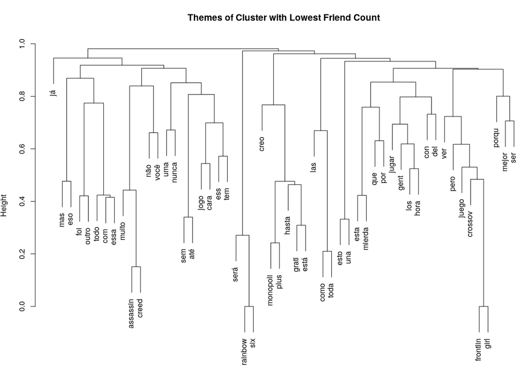

```r
## Filter the Data To match the Cluster
tweet_weighted_dtm_c1 <- tweet_weighted_dtm[pca_data$Cluster==3, ]

## Choose terms of a given frequency to reduce the dimensions
frequent.words = which(colSums(tweet_weighted_dtm_c1 > 0) > 3)
term.matrix = tweet_weighted_dtm_c1[,frequent.words]

## In order to use the Cosine Distance Make each vector have a
## magnitude of 1
unit_term.matrix = term.matrix %*% diag(1/sqrt(colSums(term.matrix^2)))

## Preserve the column Names
colnames(unit_term.matrix) = colnames(term.matrix)
colnames(unit_term.matrix)

## Find the Cosine Distance between the Terms
## (Distance between terms so transpose)
t(unit_term.matrix)
D = dist(t(unit_term.matrix), method = "euclidean")^2/2

## Perform Heirarchical Clustering
h = hclust(D, method="complete")
plot(h, main = "Themes of Cluster with Lowest Friend Count")
```

## 8.2.23 Conclusion

It appears that users that discuss newer titles and upcoming collaborations belong to a cluster with a higher proportion of users with an above average friend count, whereas users that discuss older titles (such as *Assasins Creed* as demonstrated in figure *dn3*) tend to belong to a cluster with a lower proportion of users with high friend counts.

This could imply that users discussing new titles are more likely to have more friends or it could imply that twitter users with a high friend count are more likely to show interest in newer titles and material.

# 8.3 Building Networks

## 8.3.24 Find the 10 Most Popular Friends of the Twitter Handle

The `get_friends` function can be used to discover the friends of the [@ubisoft](https://twitter.com/Ubisoft) account, these user *ID* values can then be passed as an argument to the `lookup_users` function, this will return the features of those given users and these results can be sorted by friend count in order to show the most popular friends, as shown in listing *fdg*, this provides the following list of friends in order of the number of there popularity:

| 1. `BarackObama` | 2. `XboxSupport` | 3. `DEADLINE` | 4. `gameinformer` | 5. `Arbys` |
| --- | --- | --- | --- | --- |
| 6. `PeterHollens` | 7. `HarleyPlays` | 8. `G4C` | 9. `Xbox` | 10. `GailSimone` |

Use `rtweet` to obtain the friends of *Ubisoft* with the most friends

```r
## * 8.2.24 Find 10 Most Popular Friends of the Twitter Handle
## ## ** Get the User ID of Friends of Ubisoft
t <- get_friends("ubisoft", token = tk)
## *** Get More Information of Friends
friends = lookup_users(t$user_id, token = tk)
## **** Inspect the friends
dim(friends)
names(friends)

friends$screen_name[1] #name of friend at index 1
friends$followers_count[1] #examine the follower count of the first friend
friends$screen_name[2]

## ** Find the 10 Most Popular Friends
friendPosition = order(friends$friends_count, decreasing = TRUE)[1:10]
topFriends = friends[friendPosition,] #ids of top 10 friends
## *** Print the top 10 most popular friends
topFriends$screen_name

## [1] "BarackObama"  "XboxSupport"  "DEADLINE"     "gameinformer" "Arbys"
## [6] "PeterHollens" "HarleyPlays"  "G4C"          "Xbox"         "GailSimone"
```

# Appendix

## Users with High Friend Count

User ID and Friend Count of users with above highest friend count in sample

| *User ID* | *Friend Count* |
| --- | --- |
| 274488119 | 8752 |
| 743771665 | 5002 |
| 1036014247 | 4999 |
| 2281452613 | 4992 |
| 1554453560 | 4958 |
| 981233818408570880 | 4944 |
| 931765564388921344 | 4836 |
| 807405140 | 4710 |
| 1112579152970842112 | 4514 |
| 2441577446 | 4322 |
| 552692862 | 4229 |
| 956297007127252992 | 3976 |
| 22493896 | 3675 |
| 255922782 | 3500 |
| 1067409881332936709 | 3312 |
| 27998570 | 3210 |
| 715118521555017728 | 3099 |
| 2356170174 | 2885 |
| 2372688230 | 2880 |
| 1868357425 | 2719 |

## Users with Low Friend Count

| *User ID* | *Friend Count* |
| --- | --- |
| 1254280995592966145 | 0 |
| 875126772978913280 | 0 |
| 1254256124217319425 | 0 |
| 1250219450210480128 | 0 |
| 1214921087328411648 | 0 |
| 1254115699628421120 | 0 |
| 1217600080376520704 | 0 |
| 1253480062453600257 | 0 |
| 1254178435502571521 | 0 |
| 1251955545092718592 | 0 |
| 1106864828700712960 | 0 |
| 1160744587620524032 | 0 |
| 1254256536710504448 | 1 |
| 1129040408384868352 | 1 |
| 1254121201871589376 | 1 |
| 1248687797755658243 | 2 |
| 1210265263867932675 | 2 |
| 3380784928 | 3 |
| 1177274165239275520 | 3 |
| 54645521 | 3 |

## TF-IDF Matrix

Document Term Matrix of first 6 documents and first 6 Words

| **check** | **coronavirus** | **death** | **first** | **gone** | **hour** |
| --- | --- | --- | --- | --- | --- |
| 0.615 | 0.747 | 0.830 | 0.596 | 0.747 | 0.698 |
| 0 | 0 | 0 | 0 | 0 | 0 |
| 0 | 0 | 0 | 0 | 0 | 0 |
| 0 | 0 | 0 | 0 | 0 | 0 |
| 0 | 0 | 0 | 0 | 0 | 0 |
| 0 | 0 | 0 | 0 | 0 | 0 |

## Relevant XKCD

[figure not shown]

# Footnotes

[^1]: This works because the `tm` package preserves the order of the data, this can be confirmed by using a dataframe source as opposed to a vector source (e.g. in listing *cpmk*) and comparing the ID's before/after transformation.
[^2]: The `[` function is actually shorthand for `Extract()`, most things in *R* are functions, this is similar to *LISP* and has to do with the origins of the language, e.g. `sum(1:10) == (sum (1:10))`, also relevant see the relevant xkcd in figure *xkcd*.
[^3]: It is important not to filter based the logic of an empty vector, because otherwise an empty vector will returned, hence the if statement in listing *emp*.